# Getting started with R - Code and exercises

## 4.4 Rename()

The `rename()` function (from dplyr) is used to rename variables in a dataset. It allows you to provide new, meaningful names to columns while preserving the dataset’s structure. You can use it to

- To improve the readability and interpretability of your dataset.
- To standardize variable names for consistency in analysis.
- To simplify long or complex variable names.

We will show some examples here. To stay consistent with the codebook, we will keep working with the original variable names afterwards.

### 4.4.1 Examples

**Basic: Renaming one variable**

```r
# Rename a single variable
dn <- df %>%
      rename(gender = RIAGENDR)

# View the result
colnames(dn)
```

```
[1] "SEQN"     "gender"   "RIDAGEYR" "BMXWT"    "BMXHT"
```

**Options**: You can also rename multiple variables in one flow.

- **Renaming multiple single variables at once**

  ```r
  # Rename multiple variables
  dn <- df %>%
      rename(
        ID = SEQN,
        gender = RIAGENDR,
        age = RIDAGEYR,
        weight = BMXWT,
        height = BMXHT
      )

  # View the results
  colnames(dn)
  ```

  ```
  [1] "ID"     "gender" "age"    "weight" "height"
  ```

- **Renaming variables based on patterns**: Add a prefix, suffix, or replace variable names that have some common patterns in their name.

  ```r
  # Option 1: Add a prefix to all variables
  di <- df %>%
    rename_with(~ paste0("NHANES_", .))

  # Breakdown of the rename_with code
  # ~ (tilde): In general, the tilde creates an anonymous function for rename_with to apply paste0 to each column name. In simple words, it tells R in this case "For each column name, do the following"
  # paste0: This tells R to join strings without spaces
  # ("NHANES_",): Add "NHANES_" to the beginning of each column name.
  # . : Represents each column name (a placeholder for the current column name being processed).

  # View the result
  colnames(di)
  ```

  ```
  [1] "NHANES_SEQN"     "NHANES_RIAGENDR" "NHANES_RIDAGEYR" "NHANES_BMXWT"
  [5] "NHANES_BMXHT"
  ```

  ```r
  # Option 2: Add a suffix "_new" to variables starting with "BMX"
  di <- df %>%
    rename_with(~ paste0(., "_new"), starts_with("BMX"))

  # View the updated column names
  colnames(di)
  ```

  ```
  [1] "SEQN"      "RIAGENDR"  "RIDAGEYR"  "BMXWT_new" "BMXHT_new"
  ```

  ```r
  # Option 3: Replace "BMX" with "body" in variable names
  di <- df %>%
    rename_with(~ sub("^BMX", "body", .), starts_with("BMX"))

  # Breakdown of the rename_with code
  # ~ sub: In general, this tells R to find pattern in a certain string and it with something you specify. The string pattern and replacement you specify in the following brackets.
  # ^: Indicates to look only for the start of the string.
  # "BMX": Matches the prefix BMX at the start of the column name
  # "body": This is the replacement you specify for body
  # . : Represents each column being processed
  # ("NHANES_",): Add "NHANES_" to the beginning of each column name.
  # . : Represents each column name (a placeholder for the current column name being processed).

  # View the updated column names
  colnames(di)
  ```

  ```
  [1] "SEQN"     "RIAGENDR" "RIDAGEYR" "bodyWT"   "bodyHT"
  ```

- **Optional - Adding variable labels:** If you also want to label your variables, you can use the labelled-package.

  ```r
  # Assigning one variable label:
  var_label(dn$gender) <- "Gender of participant"
  # Check the label
  var_label(dn$gender)
  ```

  ```
  [1] "Gender of participant"
  ```

  ```r
  # You can also create a list and create multiple variable labels at once and assign them to a variabel:
  var_label(dn) <- list(
    ID = "Participant id",
    gender = "Gender of participant",
    age = "Age at study",
    weight = "Weight in kg",
    height = "Height in kg"
  )

  # Check labels
  var_label(dn)
  ```

  ```
  $ID
  [1] "Participant id"

  $gender
  [1] "Gender of participant"

  $age
  [1] "Age at study"

  $weight
  [1] "Weight in kg"

  $height
  [1] "Height in kg"
  ```

### 4.4.2 Exercise 11: Rename

Practice renaming variables using the ds-dataframe. Assign all operations to “dt”.

1. Rename `BPXSY1` to `systolicBP`.
2. Rename `SMQ040` to `currentSmoker` and `BPXDI1` to `diastolicBP`.
3. Use `rename_with()` to replace `BPX` with `pressure` in all variables starting with `BPX`.

**Show code exercise 11**

```r
# 1. Rename BPXSY1 to systolicBP.
dt <- ds %>%
      rename(systolicBP = BPXSY1)

# 2. Rename SMQ040 to currentSmoker and BPXDI1 to diastolicBP.
dt <- ds %>%
  rename(
    currentSmoker = SMQ040,
    diastolicBP = BPXDI1
  )

# 3. Use rename_with() to replace BPX with pressure in all variables starting with BPX.
dt <- ds %>%
  rename_with(~ sub("^BPX", "pressure", .), starts_with("BPX"))
```

## 4.5 Mutate()

The `mutate()` function in the `dplyr` package is used to create new variables, modify existing ones, and perform calculations on existing data. You can use mutate to

- derive new variables for analysis (e.g., calculate BMI)
- recode or categorize variables (e.g., age groups)
- perform transformations (e.g., converting units)

### 4.5.1 Examples

- **Creating new variables**: Add a new variable. In this example, add the variable BMI (Body Mass Index: body weight in kg / (body height in m) ^2)

  ```r
  # Calculate BMI
  dn <- df %>%
    mutate(BMI = BMXWT / (BMXHT / 100)^2)

  # List column names
  head(dn)
  ```

  ```
  # A tibble: 6 × 6
     SEQN RIAGENDR RIDAGEYR BMXWT BMXHT   BMI
    <dbl>    <dbl>    <dbl> <dbl> <dbl> <dbl>
  1 93703        2        2  13.7  88.6  17.5
  2 93704        1        2  13.9  94.2  15.7
  3 93705        2       66  79.5 158.   31.7
  4 93706        1       18  66.3 176.   21.5
  5 93707        1       13  45.4 158.   18.1
  6 93708        2       66  53.5 150.   23.7
  ```

- **Modifying existing variables**: In this example, we change age (currently in years) to months. Here, we overwrite the current age-variable. It is recommended to create a new variable

  ```r
  # Convert age to months
  dn <- df %>%
    mutate(RIDAGEYR = RIDAGEYR * 12) %>%
    head %>%
    print
  ```

  ```
  # A tibble: 6 × 5
     SEQN RIAGENDR RIDAGEYR BMXWT BMXHT
    <dbl>    <dbl>    <dbl> <dbl> <dbl>
  1 93703        2       24  13.7  88.6
  2 93704        1       24  13.9  94.2
  3 93705        2      792  79.5 158.
  4 93706        1      216  66.3 176.
  5 93707        1      156  45.4 158.
  6 93708        2      792  53.5 150.
  ```

  ```r
  # Convert age to month and create a new variable
  dn <- df %>%
    mutate(age_months = RIDAGEYR * 12) %>%
    relocate(age_months, .after = RIDAGEYR) %>% # this function moves one variable after another one
    head %>%
    print
  ```

  ```
  # A tibble: 6 × 6
     SEQN RIAGENDR RIDAGEYR age_months BMXWT BMXHT
    <dbl>    <dbl>    <dbl>      <dbl> <dbl> <dbl>
  1 93703        2        2         24  13.7  88.6
  2 93704        1        2         24  13.9  94.2
  3 93705        2       66        792  79.5 158.
  4 93706        1       18        216  66.3 176.
  5 93707        1       13        156  45.4 158.
  6 93708        2       66        792  53.5 150.
  ```

- **Categorizing variables using if_else**: Especially handy for binary categorizations. You can do more categories by nesting multiple if_else functions.

  ```r
  # Categorize age into two categories
  df <- df %>%
     mutate(age_group_binary = if_else(RIDAGEYR >= 18, "adult", "child"))
  head(dn)
  ```

  ```
  # A tibble: 6 × 6
     SEQN RIAGENDR RIDAGEYR age_months BMXWT BMXHT
    <dbl>    <dbl>    <dbl>      <dbl> <dbl> <dbl>
  1 93703        2        2         24  13.7  88.6
  2 93704        1        2         24  13.9  94.2
  3 93705        2       66        792  79.5 158.
  4 93706        1       18        216  66.3 176.
  5 93707        1       13        156  45.4 158.
  6 93708        2       66        792  53.5 150.
  ```

  ```r
  # Categorize age into three categories
  df <- df %>%
      mutate(age_group_three =
              if_else(RIDAGEYR < 13, "child",
                if_else(RIDAGEYR >= 13 & RIDAGEYR < 18, "teenager", "adult")
              ))
  head(df)
  ```

  ```
  # A tibble: 6 × 7
     SEQN RIAGENDR RIDAGEYR BMXWT BMXHT age_group_binary age_group_three
    <dbl>    <dbl>    <dbl> <dbl> <dbl> <chr>            <chr>
  1 93703        2        2  13.7  88.6 child            child
  2 93704        1        2  13.9  94.2 child            child
  3 93705        2       66  79.5 158.  adult            adult
  4 93706        1       18  66.3 176.  adult            adult
  5 93707        1       13  45.4 158.  child            teenager
  6 93708        2       66  53.5 150.  adult            adult
  ```

- **Categorizing variables using case_when:** For categorizing variables, case_when is more flexibel for multiple conditions (> 2).

  ```r
  # Categorize BMI
  df <- df %>%
    mutate(BMI = BMXWT / (BMXHT / 100)^2) %>%
    mutate(BMI_category = case_when(
      BMI < 18.5 ~ "underweight",
      BMI >= 18.5 & BMI < 25 ~ "normal",
      BMI >= 25 & BMI < 30 ~ "overweight",
      BMI >= 30 ~ "obese"
    ))

  head(df, n = 20)
  ```

  ```
  # A tibble: 20 × 9
      SEQN RIAGENDR RIDAGEYR BMXWT BMXHT age_group_binary age_group_three   BMI
     <dbl>    <dbl>    <dbl> <dbl> <dbl> <chr>            <chr>           <dbl>
   1 93703        2        2  13.7  88.6 child            child            17.5
   2 93704        1        2  13.9  94.2 child            child            15.7
   3 93705        2       66  79.5 158.  adult            adult            31.7
   4 93706        1       18  66.3 176.  adult            adult            21.5
   5 93707        1       13  45.4 158.  child            teenager         18.1
   6 93708        2       66  53.5 150.  adult            adult            23.7
   7 93709        2       75  88.8 151.  adult            adult            38.9
   8 93710        2        0  10.2  NA   child            child            NA
   9 93711        1       56  62.1 171.  adult            adult            21.3
  10 93712        1       18  58.9 173.  adult            adult            19.7
  11 93713        1       67  74.9 179.  adult            adult            23.5
  12 93714        2       54  87.1 148.  adult            adult            39.9
  13 93715        1       71  65.6 171.  adult            adult            22.5
  14 93716        1       61  77.7 159.  adult            adult            30.7
  15 93717        1       22  74.4 174.  adult            adult            24.5
  16 93718        1       45  54.4 157.  adult            adult            22.0
  17 93719        2       13  67   160.  child            teenager         26.0
  18 93720        2        1  10.6  NA   child            child            NA
  19 93721        2       60  85.1 154   adult            adult            35.9
  20 93722        2       60  56.8 155.  adult            adult            23.8
  # ℹ 1 more variable: BMI_category <chr>
  ```

### 4.5.2 Exercise 12: Mutate

Use again your dataset “ds” and assign all operations to this dataset (ds).

**Show code exercise 12**

```r
# 1. Create Pulse_Pressure variable
ds <- ds %>%
  mutate(pulse_pressure = BPXSY1 - BPXDI1)

# 2. Create Smoker_Status using if_else()
ds <- ds %>%
  mutate(smoker_status = if_else(SMQ040 == 3, 0, 1))

# 3. Categorize systolic blood pressure using case_when()
ds <- ds %>%
  mutate(bp_category = case_when(
    BPXSY1 < 120 ~ "normal",
    BPXSY1 >= 120 & BPXSY1 < 140 ~ "elevated",
    BPXSY1 >= 140 ~ "hypertension"
  ))
```

## 4.6 Class conversions

Class conversions are essential to transform variable types. You use them to

- prepare data for analysis (e.g., converting strings to factors for categorical variables).
- fixing data import issues (e.g., when numeric values are read as characters).
- customize variable types for specific functions (e.g., some models require factors).

### 4.6.1 Examples

There are different conversions available:

- **String (character) to factor**: To convert a character/string into a factor variable.

  ```r
  # Example: Convert BMI (character) to a factor
  df <- df %>%
    mutate(BMI_category = as.factor(BMI_category))

  # Check the class of the variable
  class(df$BMI_category)
  ```

  ```
  [1] "factor"
  ```

  ```r
  levels(df$BMI_category)
  ```

  ```
  [1] "normal"      "obese"       "overweight"  "underweight"
  ```

  As you can see, R orders the levels alphabetically if not specified otherwise. We can specify the level order using an adapted code:

  ```r
  df <- df %>%
          mutate(BMI_category = factor(BMI_category,
                                       levels = c("underweight", "normal", "overweight", "obese")))

  # Check the class of the variable
  class(df$BMI_category)
  ```

  ```
  [1] "factor"
  ```

  ```r
  levels(df$BMI_category)
  ```

  ```
  [1] "underweight" "normal"      "overweight"  "obese"
  ```

  ```r
  # Optional: If you want to set a different reference category, you can use the relevel() function
  dn <- df %>%
          mutate(BMI_category = relevel(BMI_category, ref = "normal"))
  levels(dn$BMI_category)
  ```

  ```
  [1] "normal"      "underweight" "overweight"  "obese"
  ```

- **Numeric to factor:** Useful for categorical variables stored as numbers.

  ```r
  # Example: Convert Gender (numeric) to a factor
  dn <- df %>%
    mutate(RIAGENDR = as.factor(RIAGENDR))
  class(dn$RIAGENDR)
  ```

  ```
  [1] "factor"
  ```

  ```r
  levels(dn$RIAGENDR)
  ```

  ```
  [1] "1" "2"
  ```

  ```r
  # Optionally, you can also assign value labels
  df <- df %>%
        mutate(RIAGENDR = factor(RIAGENDR,
                                 levels = c(1, 2),
                                 labels = c("male", "female")))
  # Check the result
  class(df$RIAGENDR)
  ```

  ```
  [1] "factor"
  ```

  ```r
  levels(df$RIAGENDR)
  ```

  ```
  [1] "male"   "female"
  ```

  ```r
  nlevels(df$RIAGENDR) # Gives you the number of levels
  ```

  ```
  [1] 2
  ```

- **Factor to numeric**: When you import datasets, it can happen that a numeric variable is recognized as a factor variable, which you then have to change:

  ```r
  df <- df %>%
    mutate(RIAGENDR_incorrect = as.numeric(RIAGENDR))
  head(df)
  ```

  ```
  # A tibble: 6 × 10
     SEQN RIAGENDR RIDAGEYR BMXWT BMXHT age_group_binary age_group_three   BMI
    <dbl> <fct>       <dbl> <dbl> <dbl> <chr>            <chr>           <dbl>
  1 93703 female          2  13.7  88.6 child            child            17.5
  2 93704 male            2  13.9  94.2 child            child            15.7
  3 93705 female         66  79.5 158.  adult            adult            31.7
  4 93706 male           18  66.3 176.  adult            adult            21.5
  5 93707 male           13  45.4 158.  child            teenager         18.1
  6 93708 female         66  53.5 150.  adult            adult            23.7
  # ℹ 2 more variables: BMI_category <fct>, RIAGENDR_incorrect <dbl>
  ```

  ```r
  # Drop again
  df <- df %>%
    select(- RIAGENDR_incorrect)
  ```

### 4.6.2 Exercise 13: Class conversions

Work again with your dataframe “ds” and assign all operations to the dataframe “ds”.

1. Convert smoker_status from numeric to a factor with the following labels:
   - `0`: “no smoker”
   - `1`: “current smoker”
2. Convert the variable `bp_category` from string to factor variable. Order the levels the following: “normal”, “elevated”, “hypertension”.

   **Show code exercise 13**

   ```r
   # 1. Convert SMQ040 (smoking status) from numeric to a factor with the following labels:
   ds <- ds %>%
     mutate(smoker_status = factor(smoker_status,
                           levels = c(0, 1),
                           labels = c("no smoker", "current smoker")))


   # 2. Convert the variable bp_category from string to factor variable. Order the levels the following: "normal", "elevated", "high".
   ds <- ds %>%
     mutate(bp_category = factor(bp_category,
                                 levels = c("normal", "elevated", "hypertension")))
   ```

# 5 Exploring your dataset

Now that you prepared your dataset for analysis, we can run exploratory data analysis. We do this to uncover patterns, spot anomalies, and summarize its key characteristics. It usually involves:

- **Descriptive statistics**: Summarizing individual variables (e.g., mean and median)
- **Visualizations**: Exploring distributions and relationships between variables (e.g., boxplot, correlation matrix)
- **Group comparisons**: Comparing metrics across different categories (e.g., cross-tabulations, mean by group).

We will use different packages for exploratory data analysis including tidyverse, which you already know, and the packages “table1” and “summarytools”.

## 5.1 Simple descriptive statistics

We will calculate some basic descriptive statistics for numeric and factor variables. There are various ways of doing this in R, we will show you a couple of options with Base R, tidyverse, and summarytools.

### 5.1.1 Numeric variables

- **Base R**

  ```r
  # Summary function for an overview of a single variable
  summary(df$RIDAGEYR, na.rm = FALSE)
  ```

  ```
     Min. 1st Qu.  Median    Mean 3rd Qu.    Max.
     0.00   11.00   31.00   34.33   58.00   80.00
  ```

  ```r
  # Individual calculations
  min(df$RIDAGEYR, na.rm = TRUE)    # Minimum age
  ```

  ```
  [1] 0
  ```

  ```r
  mean(df$RIDAGEYR, na.rm = TRUE)   # Mean age
  ```

  ```
  [1] 34.33423
  ```

  ```r
  median(df$RIDAGEYR, na.rm = TRUE) # Median age
  ```

  ```
  [1] 31
  ```

  ```r
  max(df$RIDAGEYR, na.rm = TRUE)    # Maximum age
  ```

  ```
  [1] 80
  ```

- **tidyverse**

  ```r
  # calculate basic descriptive statistics for one variable
  df %>%
    summarize(
      Min_Age = min(RIDAGEYR, na.rm = TRUE),
      Mean_Age = mean(RIDAGEYR, na.rm = TRUE),
      Median_Age = median(RIDAGEYR, na.rm = TRUE),
      Max_Age = max(RIDAGEYR, na.rm = TRUE)
    )
  ```

  ```
  # A tibble: 1 × 4
    Min_Age Mean_Age Median_Age Max_Age
      <dbl>    <dbl>      <dbl>   <dbl>
  1       0     34.3         31      80
  ```

  ```r
  # calculate basic descriptive statistics for multiple variables

  df %>%
    summarize(
      across(
        c(RIDAGEYR, BMXWT, BMXHT),
        list(
          Min = ~ min(.x, na.rm = TRUE),
          Mean = ~ mean(.x, na.rm = TRUE),
          Median = ~ median(.x, na.rm = TRUE),
          Max = ~ max(.x, na.rm = TRUE)
        ),
        .names = "{.col}_{.fn}"
      )
    )
  ```

  ```
  # A tibble: 1 × 12
    RIDAGEYR_Min RIDAGEYR_Mean RIDAGEYR_Median RIDAGEYR_Max BMXWT_Min BMXWT_Mean
           <dbl>         <dbl>           <dbl>        <dbl>     <dbl>      <dbl>
  1            0          34.3              31           80       3.2       65.1
  # ℹ 6 more variables: BMXWT_Median <dbl>, BMXWT_Max <dbl>, BMXHT_Min <dbl>,
  #   BMXHT_Mean <dbl>, BMXHT_Median <dbl>, BMXHT_Max <dbl>
  ```

  ```r
  # The .names argument controls how the new column names are generated:
  # {.col} refers to the variable name (e.g., Variable1).
  # {.fn} refers to the function name (e.g., Min, Mean, etc.).
  # This ensures the output columns have clear and unique names.
  ```

- **summarytools**

  ```r
  # Detailed descriptive statistics for RIDAGEYR (Age)
  summarytools::descr(df$RIDAGEYR)
  ```

  ```
  Descriptive Statistics
  df$RIDAGEYR
  N: 9254

                      RIDAGEYR
  ----------------- ----------
               Mean      34.33
            Std.Dev      25.50
                Min       0.00
                 Q1      11.00
             Median      31.00
                 Q3      58.00
                Max      80.00
                MAD      34.10
                IQR      47.00
                 CV       0.74
           Skewness       0.28
        SE.Skewness       0.03
           Kurtosis      -1.29
            N.Valid    9254.00
          Pct.Valid     100.00
  ```

### 5.1.2 Factor variables

- **Base R**

  ```r
  # Frequency counts for gender
  table(df$RIAGENDR)
  ```

  ```
    male female
    4557   4697
  ```

  ```r
  # Proportions (relative frequencies)
  prop.table(table(df$RIAGENDR))
  ```

  ```
       male    female
  0.4924357 0.5075643
  ```

- **tidyverse**

  ```r
  # Frequency counts for RIAGENDR (Gender)
  df %>%
    count(RIAGENDR)
  ```

  ```
  # A tibble: 2 × 2
    RIAGENDR     n
    <fct>    <int>
  1 male      4557
  2 female    4697
  ```

  ```r
  # Add proportions
  df %>%
    count(RIAGENDR) %>%
    mutate(Proportion = n / sum(n)) #  # calculates the proportion of each category relative to the total count of observations
  ```

  ```
  # A tibble: 2 × 3
    RIAGENDR     n Proportion
    <fct>    <int>      <dbl>
  1 male      4557      0.492
  2 female    4697      0.508
  ```

- **summarytools**

  ```r
  freq(df$RIAGENDR)
  ```

  ```
  Frequencies
  df$RIAGENDR
  Type: Factor

                 Freq   % Valid   % Valid Cum.   % Total   % Total Cum.
  ------------ ------ --------- -------------- --------- --------------
          male   4557     49.24          49.24     49.24          49.24
        female   4697     50.76         100.00     50.76         100.00
          <NA>      0                               0.00         100.00
         Total   9254    100.00         100.00    100.00         100.00
  ```

### 5.1.3 Numeric & factor variables

If you want to create a more comprehensive overview of both numeric and factor variables, the packages summarytools and table 1 can be very helpful.

- **table1**: This is a useful function to create an overview of various variable types, and is a great format that you can also export to a word document.

  ```r
  # Descriptives for age, gender, BMI, and BMI category
  table1(~ RIAGENDR + RIDAGEYR + BMI + BMI_category,
          data = df)
  ```

  |  | Overall (N=9254) |
  | --- | --- |
  | RIAGENDR |  |
  | male | 4557 (49.2%) |
  | female | 4697 (50.8%) |
  | RIDAGEYR |  |
  | Mean (SD) | 34.3 (25.5) |
  | Median [Min, Max] | 31.0 [0, 80.0] |
  | BMI |  |
  | Mean (SD) | 26.6 (8.26) |
  | Median [Min, Max] | 25.8 [12.3, 86.2] |
  | Missing | 1249 (13.5%) |
  | BMI_category |  |
  | underweight | 1459 (15.8%) |
  | normal | 2195 (23.7%) |
  | overweight | 1953 (21.1%) |
  | obese | 2398 (25.9%) |
  | Missing | 1249 (13.5%) |

  ```r
  # Descriptives and omitting missings for each variable
  table1(~ RIAGENDR + RIDAGEYR + BMI + BMI_category,
          data = df,
          render.missing = NULL)
  ```

  |  | Overall (N=9254) |
  | --- | --- |
  | RIAGENDR |  |
  | male | 4557 (49.2%) |
  | female | 4697 (50.8%) |
  | RIDAGEYR |  |
  | Mean (SD) | 34.3 (25.5) |
  | Median [Min, Max] | 31.0 [0, 80.0] |
  | BMI |  |
  | Mean (SD) | 26.6 (8.26) |
  | Median [Min, Max] | 25.8 [12.3, 86.2] |
  | BMI_category |  |
  | underweight | 1459 (15.8%) |
  | normal | 2195 (23.7%) |
  | overweight | 1953 (21.1%) |
  | obese | 2398 (25.9%) |

- **summarytools**: The function “dfSummary” creates a comprehensive overview of dataframe, including basic descriptive statistics, value codings, histogramms / bar plots, and missings.

  ```r
  # Summary of dataframe df
  dfSummary(df)
  ```

  ```
  Data Frame Summary
  df
  Dimensions: 9254 x 9
  Duplicates: 0

  ------------------------------------------------------------------------------------------------------------------------
  No   Variable           Stats / Values                 Freqs (% of Valid)     Graph                 Valid      Missing
  ---- ------------------ ------------------------------ ---------------------- --------------------- ---------- ---------
  1    SEQN               Mean (sd) : 98329.5 (2671.5)   9254 distinct values   : : : : : : : : : :   9254       0
       [numeric]          min < med < max:                                      : : : : : : : : : :   (100.0%)   (0.0%)
                          93703 < 98329.5 < 102956                              : : : : : : : : : :
                          IQR (CV) : 4626.5 (0)                                 : : : : : : : : : :
                                                                                : : : : : : : : : :

  2    RIAGENDR           1. male                        4557 (49.2%)           IIIIIIIII             9254       0
       [factor]           2. female                      4697 (50.8%)           IIIIIIIIII            (100.0%)   (0.0%)

  3    RIDAGEYR           Mean (sd) : 34.3 (25.5)        81 distinct values     :                     9254       0
       [numeric]          min < med < max:                                      : .                   (100.0%)   (0.0%)
                          0 < 31 < 80                                           : :           .
                          IQR (CV) : 47 (0.7)                                   : : : : : : : : : :
                                                                                : : : : : : : : : :

  4    BMXWT              Mean (sd) : 65.1 (32.9)        1405 distinct values       :                 8580       674
       [numeric]          min < med < max:                                          : :               (92.7%)    (7.3%)
                          3.2 < 67.8 < 242.6                                    :   : :
                          IQR (CV) : 42.5 (0.5)                                 : : : : .
                                                                                : : : : : .

  5    BMXHT              Mean (sd) : 156.6 (22.3)       1033 distinct values                 :       8016       1238
       [numeric]          min < med < max:                                                  : :       (86.6%)    (13.4%)
                          78.3 < 161.9 < 197.7                                              : : .
                          IQR (CV) : 19.8 (0.1)                                             : : :
                                                                                  . . . . : : : : .

  6    age_group_binary   1. adult                       5856 (63.3%)           IIIIIIIIIIII          9254       0
       [character]        2. child                       3398 (36.7%)           IIIIIII               (100.0%)   (0.0%)

  7    age_group_three    1. adult                       5856 (63.3%)           IIIIIIIIIIII          9254       0
       [character]        2. child                       2647 (28.6%)           IIIII                 (100.0%)   (0.0%)
                          3. teenager                     751 ( 8.1%)           I

  8    BMI                Mean (sd) : 26.6 (8.3)         7900 distinct values     :                   8005       1249
       [numeric]          min < med < max:                                      . : :                 (86.5%)    (13.5%)
                          12.3 < 25.8 < 86.2                                    : : :
                          IQR (CV) : 10.9 (0.3)                                 : : : .
                                                                                : : : : .

  9    BMI_category       1. underweight                 1459 (18.2%)           III                   8005       1249
       [factor]           2. normal                      2195 (27.4%)           IIIII                 (86.5%)    (13.5%)
                          3. overweight                  1953 (24.4%)           IIII
                          4. obese                       2398 (30.0%)           IIIII
  ------------------------------------------------------------------------------------------------------------------------
  ```

  ```r
  # Summary of dataframe df as html-output
  view(dfSummary(df))
  ```

  ```
  Switching method to 'browser'
  ```

  ```
  Output file written: C:\Users\cn23r745\AppData\Local\Temp\Rtmp4M1CKL\file8b0061a3282a.html
  ```

### 5.1.4 Exercise 14: Simple descriptive statistics

Use your dataframe ds for the following exercises.

1. Calculate basic descriptive statistics (minimum, mean, median, and maximum) for the following numeric variables: `BPXSY1` (systolic blood pressure), `BPXDI1` (diastolic blood pressure).
2. Summarize frequencies and proportions for `bp_category` (blood pressure category) and `smoker_status`.

**Show code exercise 14**

```r
# 1. Calculate basic descriptive statistics (minimum, mean, median, and maximum) for the following numeric variables: BPXSY1 (systolic blood pressure), BPXDI1 (diastolic blood pressure).

## Base R

# BPXSY1 (Systolic blood pressure)
summary(ds$BPXSY1)
min(ds$BPXSY1, na.rm = TRUE)
mean(ds$BPXSY1, na.rm = TRUE)
median(ds$BPXSY1, na.rm = TRUE)
max(ds$BPXSY1, na.rm = TRUE)

# BPXDI1 (Diastolic blood pressure)
summary(ds$BPXDI1)
min(ds$BPXDI1, na.rm = TRUE)
mean(ds$BPXDI1, na.rm = TRUE)
median(ds$BPXDI1, na.rm = TRUE)
max(ds$BPXDI1, na.rm = TRUE)


## tidyverse

ds %>% # specifying for each variable on its own
  summarize(
    Min_Systolic = min(BPXSY1, na.rm = TRUE),
    Mean_Systolic = mean(BPXSY1, na.rm = TRUE),
    Median_Systolic = median(BPXSY1, na.rm = TRUE),
    Max_Systolic = max(BPXSY1, na.rm = TRUE),
    Min_Diastolic = min(BPXDI1, na.rm = TRUE),
    Mean_Diastolic = mean(BPXDI1, na.rm = TRUE),
    Median_Diastolic = median(BPXDI1, na.rm = TRUE),
    Max_Diastolic = max(BPXDI1, na.rm = TRUE)
  )


ds %>% # using summarize across
  summarize(
      across(
        c(BPXSY1, BPXDI1),
          list(
            Min = ~ min(.x, na.rm = TRUE),
            Mean = ~ mean(.x, na.rm = TRUE),
            Median = ~median(.x, na.rm = TRUE),
            Max =  ~max(.x, na.rm = TRUE)
          ),
        .names = "{.col}_{.fn}")
     )



## summarytools
descr(ds$BPXSY1)
descr(ds$BPXDI1)




# 2. Summarize frequencies and proportions for bp_category (blood pressure category) and smoker_status.


## Base R

# Frequency and proportions for bp_category
table(ds$bp_category)
prop.table(table(ds$bp_category))

# Frequency and proportions for smoker_status
table(ds$smoker_status)
prop.table(table(ds$smoker_status))




## tidyverse

# Frequency and proportions for bp_category
ds %>%
  count(bp_category) %>%
  mutate(Proportion = n / sum(n))

# Frequency and proportions for smoker_status
ds %>%
  count(smoker_status) %>%
  mutate(Proportion = n / sum(n))


## summarytools
freq(ds$bp_category)
freq(ds$smoker_status)


## Tasks 1 & 2 together

# using table1
table1(~ BPXSY1 + BPXDI1 + bp_category + smoker_status,
       data = ds)

# using summarytools
dfSummary(ds)
```

## 5.2 Visual inspection

While descriptive statistics are helpful, any exploratory data analysis requires visual inspection to

- explore variable distributions
- assess the spread of data and outliers
- examine relationships between two numeric variables
- visualize categorical data

**Note on visualizations**: For better customization and aesthetics, **ggplot2** can all charts we show below and much more with enhanced visual appeal, combining different data types and layers. However, if you want to just have a quick visualization of your data, Base R is often quicker and faster. Due to the complexity of ggplot2, we won’t go there today, but we strongly recommend to check it out if you want to create figures for publications.

### 5.2.1 Histograms

Histograms display the distribution of a numeric variable by dividing it into intervals (bins) and showing the frequency of observations in each interval.

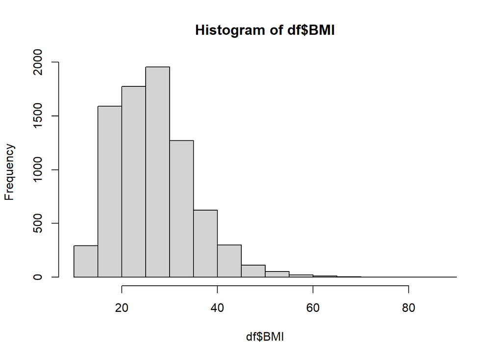

```r
# Basic version
hist(df$BMI)
```

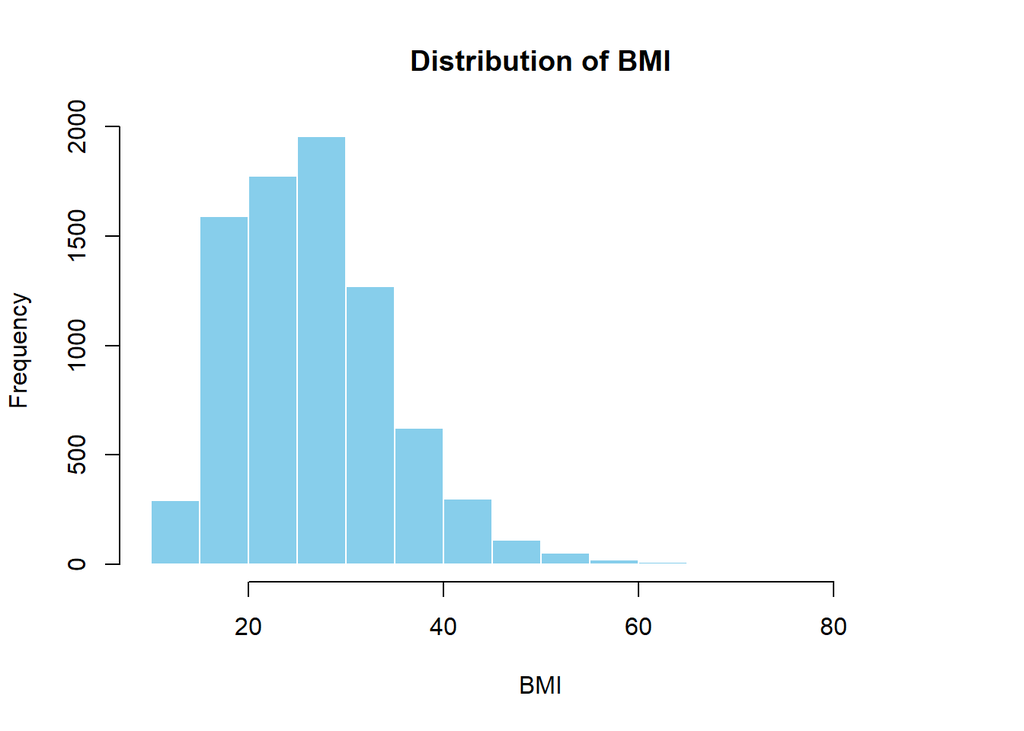

```r
# Plot with some specifications
hist(
  df$BMI,
  main = "Distribution of BMI",
  xlab = "BMI",
  col = "skyblue",
  border = "white"
)
```

### 5.2.2 Boxplots

Boxplots summarize the distribution of a numeric variable, highlighting median, quartiles, and potential outliers.

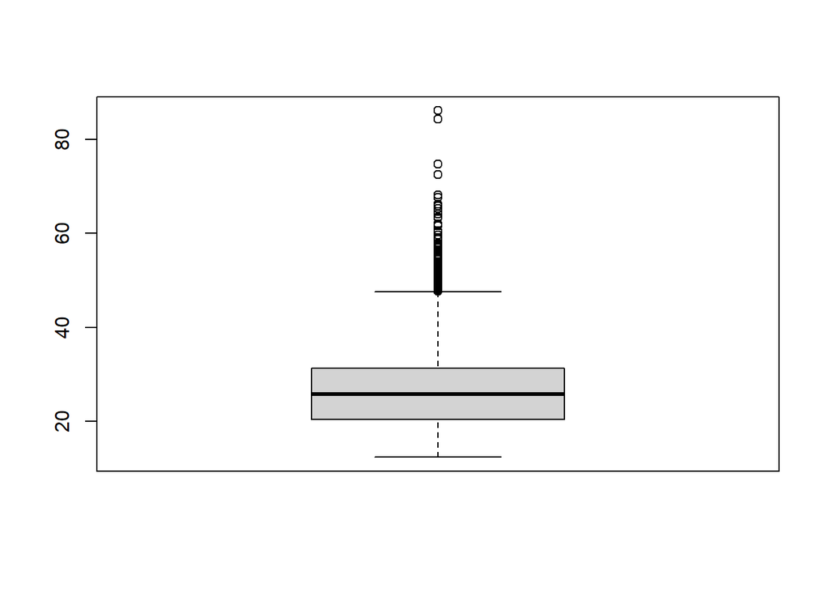

```r
# Basic boxplot
boxplot(df$BMI)
```

[figure not shown]

```r
# Boxplot stratified and adapted (BMI by age group)
boxplot(
  BMI ~ age_group_three,
  data = df,
  main = "BMI by Gender",
  xlab = "Age group",
  ylab = "BMI",
  col = c("lightblue", "lightgreen", "lightyellow")
)
```

### 5.2.3 Scatterplot

Scatterplots are used to explore relationships between two numeric variables.

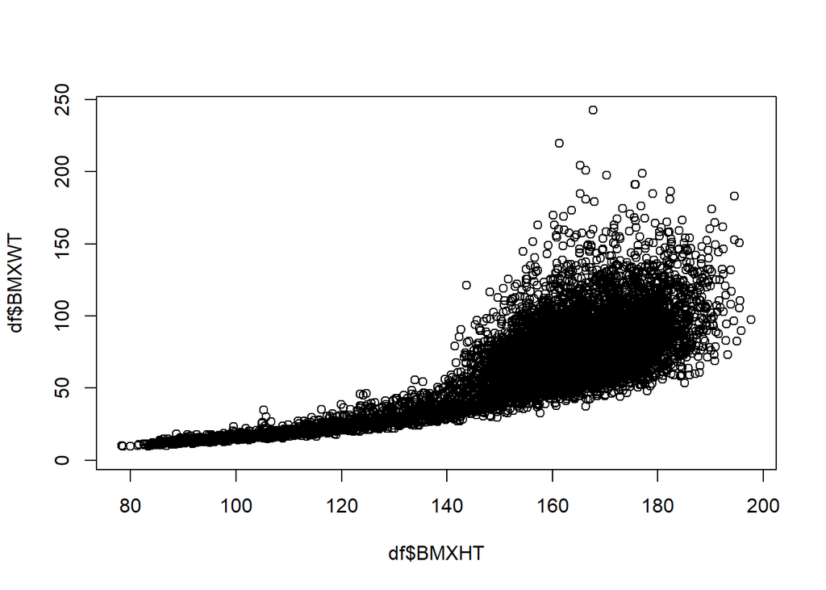

```r
# Basic scatterplot
plot(df$BMXHT, df$BMXWT)
```

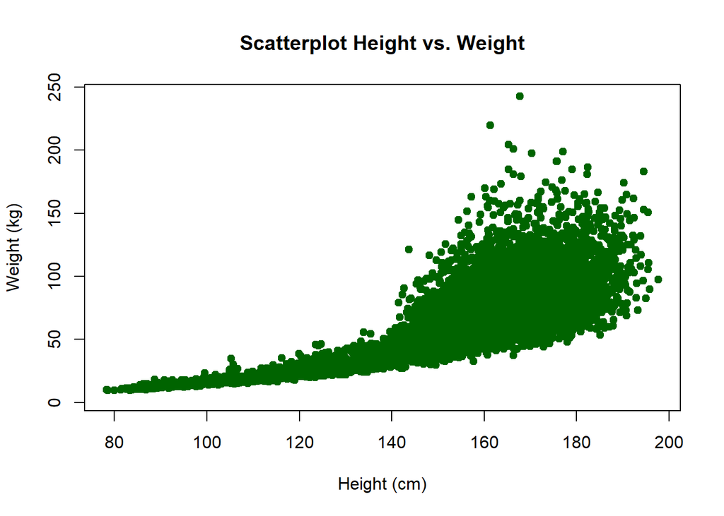

```r
# Scatterplot with some specifications
plot(
  df$BMXHT, df$BMXWT,
  main = "Scatterplot Height vs. Weight",
  xlab = "Height (cm)",
  ylab = "Weight (kg)",
  col = "darkgreen",
  pch = 19 # with this number you can specify the shape of the points
)
```

### 5.2.4 Bar charts

Bar charts are used to visualize frequencies of categorical variables.

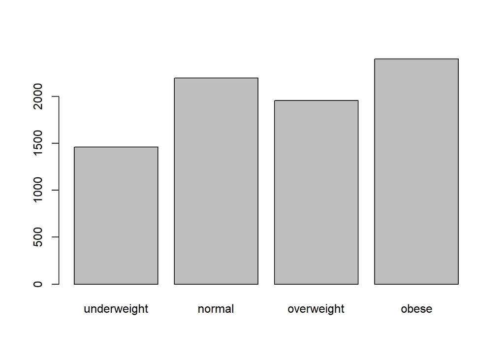

```r
# Basic bar chart
barplot(table(df$BMI_category))
```

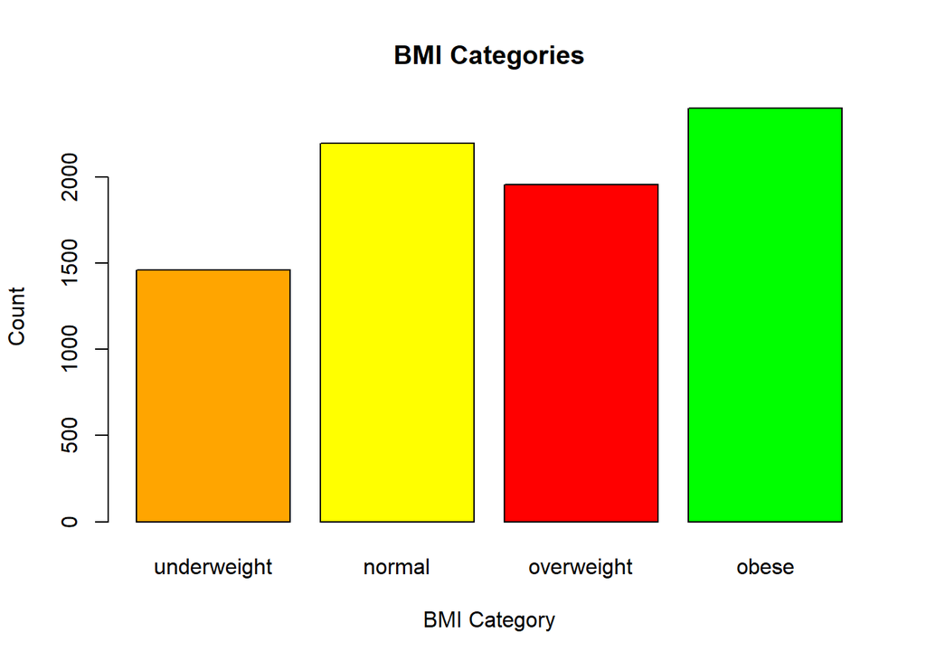

```r
# Bar chart with some specifications
barplot(table(df$BMI_category),
  main = "BMI Categories",
  xlab = "BMI Category",
  ylab = "Count",
  col = c("orange", "yellow", "red", "green")
)
```

### 5.2.5 Exercise 15: Visualizations

1. Create a histogram for `BPXSY1` (systolic blood pressure).
2. Create a boxplot for `BPXSY1` (diastolic blood pressure) and stratify by `smoker_status`. Title the figure “Blood pressure and smoker status”. Label the x-axis “Smoking status”, the y-axis “Systolic blood pressure”. Color the boxplots in blue and yellow.
3. Create a scatterplot showing the relationship between `BPXSY1` (systolic blood pressure) and `BPXDI1` (diastolic blood pressure).
4. Create a bar chart for `bp_category` (blood pressure category).

**Show code exercise 15**

```r
# 1. Create a histogram for BPXSY1 (systolic blood pressure).
hist(ds$BPXSY1)
```

**Show code exercise 15**

```r
# 2. Create a boxplot for BPXSY1 (diastolic blood pressure) and stratify by smoker_status. Title the figure "Blood pressure and smoker status". Label the x-axis "Smoking status", the y-axis "Systolic blood pressure". Color the boxplots in blue and yellow.
boxplot(
  BPXSY1 ~ smoker_status,
  data = ds,
  main = "Blood pressure and smoker status",
  xlab = "Smoker status",
  ylab = "Systolic blood pressure",
  col = c("blue", "yellow")

)
```

**Show code exercise 15**

```r
# 3. Create a scatterplot showing the relationship between BPXSY1 (systolic blood pressure) and BPXDI1 (diastolic blood pressure).
plot(ds$BPXSY1, ds$BPXDI1)
```

**Show code exercise 15**

```r
# 4. Create a bar chart for bp_category (blood pressure category).
barplot(table(ds$bp_category))
```

## 5.3 Descriptives by group

Sometimes you may want to explore descriptives separately for groups. We will go through

- grouping data by one or more categorical variables.
- calculate descriptive statistics (e.g., mean, median) for numeric variables within groups
- optionally include statistical tests for group differences

### 5.3.1 Examples

tidyverse and table1 are two helpful packages for calculating descriptives for each group.

- **tidyverse**: In tidyverse, you can use the group_by() function to arrange data based upon a factor variable (e.g., age group), and to then calculate descriptives for each group.

  ```r
  # Grouped summaries for BMI and BMXWT by age group

  df %>%
    group_by(age_group_three) %>%
    summarize(
      Mean_BMI = mean(BMI, na.rm = TRUE),
      Median_BMI = median(BMI, na.rm = TRUE),
      Mean_Weight = mean(BMXWT, na.rm = TRUE),
      Median_Weight = median(BMXWT, na.rm = TRUE),
      Count = n()
    )
  ```

  ```
  # A tibble: 3 × 6
    age_group_three Mean_BMI Median_BMI Mean_Weight Median_Weight Count
    <chr>              <dbl>      <dbl>       <dbl>         <dbl> <int>
  1 adult               29.7       28.5        82.5          78.9  5856
  2 child               18.3       16.9        25.4          21.0  2647
  3 teenager            24.5       22.9        67.8          62.8   751
  ```

- **table1**: You can also use table 1 to stratify calculations by certain groups, using the “|” operator.

  ```r
  # Summary table for BMI and BMXWT grouped by age_group and with testing

  table1(~ BMI + BMXWT | age_group_three,
         data = df)
  ```

  |  | adult (N=5856) | child (N=2647) | teenager (N=751) | Overall (N=9254) |
  | --- | --- | --- | --- | --- |
  | BMI |  |  |  |  |
  | Mean (SD) | 29.7 (7.44) | 18.3 (4.15) | 24.5 (6.40) | 26.6 (8.26) |
  | Median [Min, Max] | 28.5 [14.2, 86.2] | 16.9 [12.3, 44.1] | 22.9 [13.2, 50.6] | 25.8 [12.3, 86.2] |
  | Missing | 422 (7.2%) | 792 (29.9%) | 35 (4.7%) | 1249 (13.5%) |
  | BMXWT |  |  |  |  |
  | Mean (SD) | 82.5 (23.0) | 25.4 (16.4) | 67.8 (20.0) | 65.1 (32.9) |
  | Median [Min, Max] | 78.9 [32.6, 243] | 21.1 [3.20, 105] | 62.8 [29.3, 155] | 67.8 [3.20, 243] |
  | Missing | 412 (7.0%) | 227 (8.6%) | 35 (4.7%) | 674 (7.3%) |

### 5.3.2 Exercise 16: Descriptives by group

1. Use tidyverse to
   - filter for participants without missings for `BPXSY1`
   - group the dataset by `bp_category`
   - calculate the mean and median for `BPXSY1` (systolic blood pressure)
2. Using table1, create a summary table for `pulse_pressure` stratified by `RIAGENDR`.

**Show code exercise 16**

```r
# 1. Use tidyverse to filter for participants without missings for BPXSY1, group the dataset by bp_category calculate the mean and median for BPXSY1 (systolic blood pressure)

ds %>%
  filter(!is.na(BPXSY1)) %>%
  group_by(bp_category) %>%
  summarize(
    mean_Systolic = mean(BPXSY1, na.rm = TRUE),
    median_Systolic = median(BPXSY1, na.rm = TRUE),
    count = n()
  )


# 2. Using table1, create a summary table for pulse_pressure stratified by RIAGENDR

table1(~ pulse_pressure | RIAGENDR,
       data = ds)
```

## 5.4 Cross-tabulations

To assess associations between categorical variables, you need contigency tables or cross-tabulations. To do those, you can again work with Base R, tidyverse, and summarytools.

### 5.4.1 Examples

- **Base R**

  ```r
  # Frequency table of age_group and BMI_category
  table(df$age_group_three, df$BMI_category)
  ```

  ```
             underweight normal overweight obese
    adult            100   1382       1725  2227
    child           1262    448        101    44
    teenager          97    365        127   127
  ```

  ```r
  # Proportion table
  prop.table(table(df$age_group_three, df$BMI_category), margin = 1)
  ```

  ```
             underweight     normal overweight      obese
    adult     0.01840265 0.25432462 0.31744571 0.40982702
    child     0.68032345 0.24150943 0.05444744 0.02371968
    teenager  0.13547486 0.50977654 0.17737430 0.17737430
  ```

  ```r
  # margin = 1 gives you row-wise proportions, margin = 2 column-wise proportions
  ```

- **table1**

  ```r
  # BMI category by age group
  table1(~ BMI_category | age_group_three,
         render.missing = NULL, # take this out if you also want to see the missings
         data = df)
  ```

  |  | adult (N=5856) | child (N=2647) | teenager (N=751) | Overall (N=9254) |
  | --- | --- | --- | --- | --- |
  | BMI_category |  |  |  |  |
  | underweight | 100 (1.7%) | 1262 (47.7%) | 97 (12.9%) | 1459 (15.8%) |
  | normal | 1382 (23.6%) | 448 (16.9%) | 365 (48.6%) | 2195 (23.7%) |
  | overweight | 1725 (29.5%) | 101 (3.8%) | 127 (16.9%) | 1953 (21.1%) |
  | obese | 2227 (38.0%) | 44 (1.7%) | 127 (16.9%) | 2398 (25.9%) |

- **summarytools**

  ```r
  # BMI category by age group
  ctable(df$BMI_category, df$age_group_three, prop = "r")
  ```

  ```
  Cross-Tabulation, Row Proportions
  BMI_category * age_group_three
  Data Frame: df

  -------------- ----------------- -------------- -------------- ------------- ---------------
                   age_group_three          adult          child      teenager           Total
    BMI_category
     underweight                      100 ( 6.9%)   1262 (86.5%)    97 ( 6.6%)   1459 (100.0%)
          normal                     1382 (63.0%)    448 (20.4%)   365 (16.6%)   2195 (100.0%)
      overweight                     1725 (88.3%)    101 ( 5.2%)   127 ( 6.5%)   1953 (100.0%)
           obese                     2227 (92.9%)     44 ( 1.8%)   127 ( 5.3%)   2398 (100.0%)
            <NA>                      422 (33.8%)    792 (63.4%)    35 ( 2.8%)   1249 (100.0%)
           Total                     5856 (63.3%)   2647 (28.6%)   751 ( 8.1%)   9254 (100.0%)
  -------------- ----------------- -------------- -------------- ------------- ---------------
  ```

  ```r
  # You can also drop missing, use column percentages and add a chi-square test
  ctable(df$BMI_category, df$age_group_three,
         useNA = "no",
         prop = "c",
         chisq = TRUE)
  ```

  ```
  Cross-Tabulation, Column Proportions
  BMI_category * age_group_three
  Data Frame: df


  -------------- ----------------- --------------- --------------- -------------- ---------------
                   age_group_three           adult           child       teenager           Total
    BMI_category
     underweight                      100 (  1.8%)   1262 ( 68.0%)    97 ( 13.5%)   1459 ( 18.2%)
          normal                     1382 ( 25.4%)    448 ( 24.2%)   365 ( 51.0%)   2195 ( 27.4%)
      overweight                     1725 ( 31.7%)    101 (  5.4%)   127 ( 17.7%)   1953 ( 24.4%)
           obese                     2227 ( 41.0%)     44 (  2.4%)   127 ( 17.7%)   2398 ( 30.0%)
           Total                     5434 (100.0%)   1855 (100.0%)   716 (100.0%)   8005 (100.0%)
  -------------- ----------------- --------------- --------------- -------------- ---------------

  ----------------------------
   Chi.squared   df   p.value
  ------------- ---- ---------
    4627.584     6       0
  ----------------------------
  ```

### 5.4.2 Exercise 17: Cross-tabulations

Using your dataset ds, create a contigency table of `bp_category` and `smoker_status`. Calculate column-percentages, and run a chi-square test (remember to drop missings for the chi-square test).

**Show code exercise 17**

```r
# Cross-tabulation with ctable of bp_category and smoker_status
ctable(ds$bp_category, ds$smoker_status, prop = "c", useNA = "no", chisq = TRUE)
```